# Chester’s Beer Ratings (Solutions)

We begin by loading in the dataset from this package.

```r
data(untappd, package = "izzyuntappd")
# I've also included the dataset as a CSV file and you can read it in by using
# untappd <- read_csv(file = "chester_beer_feb15-june16.csv")
```

One great feature of RStudio is the ability to view dataframes like `untappd` in table form:

```r
View(untappd)
```

# ABV

## Summary values

We can determine what the mean and median `abv` values are from this data set and also the standard deviation of the `abv` values:

```r
summary_abv <- untappd %>% summarize(mean_abv = mean(abv),
  median_abv = median(abv),
  sd_abv = sd(abv))
summary_abv
```

```
## # A tibble: 1 x 3
##   mean_abv median_abv   sd_abv
##      <dbl>      <dbl>    <dbl>
## 1 6.453058        6.2 1.830056
```

```r
kable(summary_abv)
```

| mean_abv | median_abv | sd_abv |
| --- | --- | --- |
| 6.453058 | 6.2 | 1.830056 |

## Plotting

We can also create a plot of this distribution of `abv`:

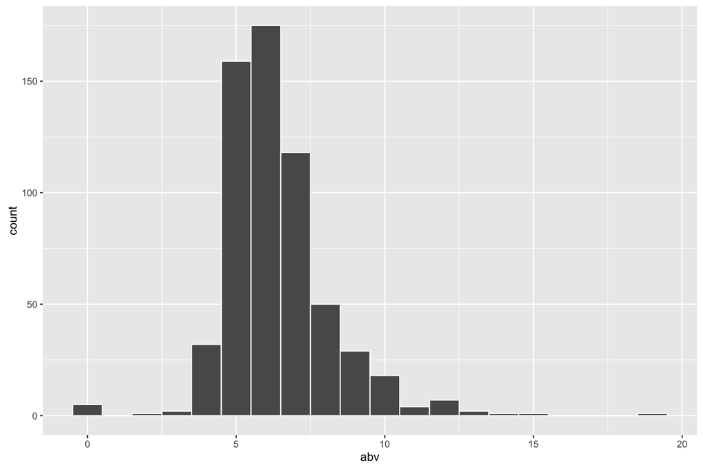

```r
abv_plot <- ggplot(aes(x = abv), data = untappd) +
  geom_histogram(bins = 20, color = "white")
abv_plot
```

To make an interactive plot using a `ggplot2` graphic, we can use the `ggplotly` function in the `plotly` package:

```r
ggplotly(abv_plot)
```

[interactive chart not shown]

# Top styles

If we’d like to see the top number of `macro_style` of beer I’ve tried, sorted:

```r
style_count <- untappd %>% count(macro_style)
datatable(style_count)
```

|  | macro_style | n |
| --- | --- | --- |
| 1 | Amber/Red | 38 |
| 2 | Blonde/Golden | 12 |
| 3 | Brown | 32 |
| 4 | Cider/Perry/Mead | 65 |
| 5 | Dark/Winter Warmer | 17 |
| 6 | Fruit/Pumpkin/Herbed | 33 |
| 7 | German | 15 |
| 8 | IPA | 140 |
| 9 | Lager/Pilsner | 25 |
| 10 | OTHER | 41 |

[output cut: 5 more lines]

The `datatable` function in the `DT` package provides a nice interface for searching and sorting datasets.

**What is going on here!?** Do I actually like my top `macro_style` as much as these numbers show?

# `dplyr` verbs

## Filtering

Let’s focus on only the `macro_style` corresponding to `IPA`. We will create a new dataframe called `ipas`:

```r
ipas <- untappd %>% filter(macro_style == "IPA")
```

Look through the dataset again by entering `View(ipas)` into the R console.

## Selecting

Let’s simplify our dataset a bit to view it more easily.

```r
ipas_small <- ipas %>% select(beer_name, style, abv, ibu, rating)
```

We might be curious to see if `ibu` has a relationship with `rating`:

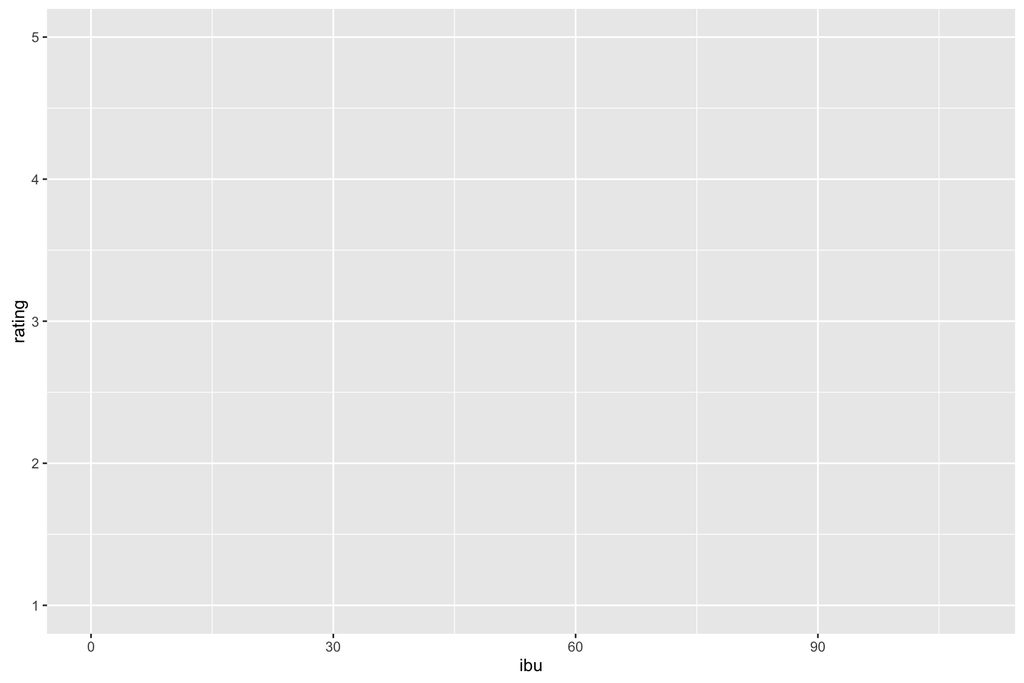

```r
ggplot(data = ipas_small, aes(x = ibu, y = rating))
```

What type of plot should we make here?

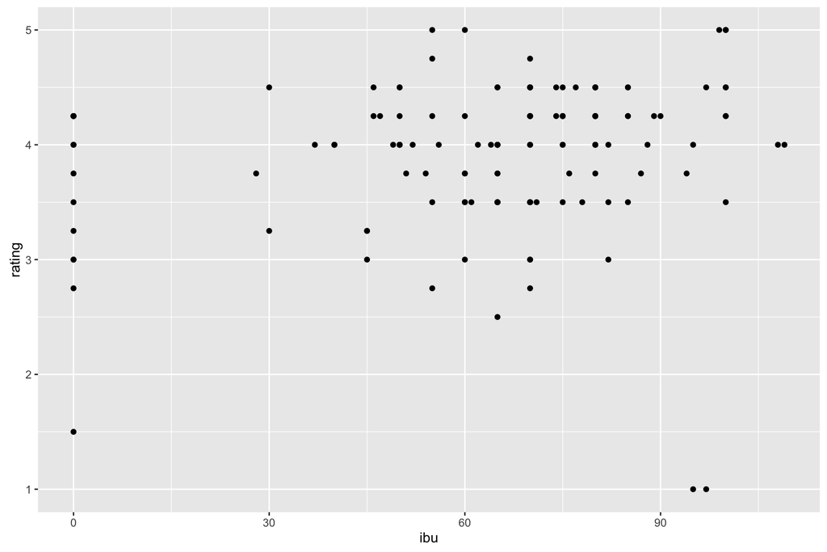

```r
ibu_vs_rating <- ggplot(data = ipas_small, aes(x = ibu, y = rating)) +
  geom_point()
ibu_vs_rating
```

It is often better to view datasets in plots by using multivariate thinking. Another common feature that beer drinkers look for is `abv`. How does `abv` relate to `ibu` and `rating` for me?

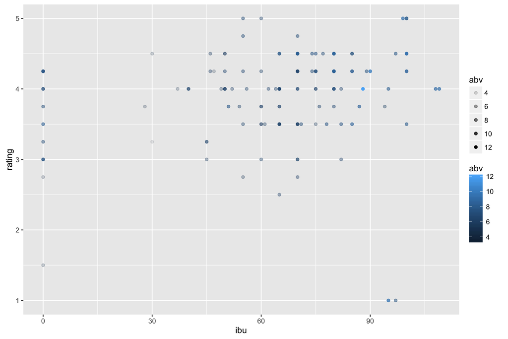

```r
ibu_abv_rating <- ggplot(data = ipas_small, aes(x = ibu, y = rating)) +
  geom_point(aes(color = abv, alpha = abv))
ibu_abv_rating
```

```r
ggplotly(ibu_abv_rating)
```

[interactive chart not shown]

## Grouping and Summarizing

There are many different styles of beers in the `macro_style` of `IPA`. How could we use what we know already to determine which style of IPA I rated highest, on average?

```r
summary_ipas <- ipas_small %>% group_by(style) %>%
  summarize(mean_rating = mean(rating),
    median_rating = median(rating),
    count = n())
datatable(summary_ipas)
```

|  | style | mean_rating | median_rating | count |
| --- | --- | --- | --- | --- |
| 1 | IPA - American | 3.92582417582418 | 4 | 91 |
| 2 | IPA - Belgian | 3.25 | 3.25 | 2 |
| 3 | IPA - Black / Cascadian Dark Ale | 4.03571428571429 | 4 | 7 |
| 4 | IPA - English | 3.875 | 3.875 | 2 |
| 5 | IPA - Imperial / Double | 4.1125 | 4.25 | 20 |
| 6 | IPA - Imperial / Double Black | 4.125 | 4.125 | 4 |
| 7 | IPA - Session / India Session Ale | 3.61111111111111 | 4 | 9 |
| 8 | IPA - Triple | 4.125 | 4.125 | 2 |
| 9 | IPA - White | 2.875 | 2.875 | 2 |
| 10 | Rye Beer / Rye IPA | 3 | 3 | 1 |

## Least favorite brewery state

Now let’s go back to the original `untappd` dataset.

- How would we determine how many different states have brewed beers I have had? You’ve seen a *hacky* way to do this above.

```r
brew_state_counts <- untappd %>% filter(brewery_country == "United States") %>% count(brewery_state)
datatable(brew_state_counts)
```

|  | brewery_state | n |
| --- | --- | --- |
| 1 | AK | 32 |
| 2 | CA | 80 |
| 3 | CO | 25 |
| 4 | DE | 3 |
| 5 | HI | 18 |
| 6 | IA | 4 |
| 7 | ID | 3 |
| 8 | IL | 5 |
| 9 | IN | 1 |
| 10 | KS | 1 |

[output cut: 15 more lines]

We see that there are 25 states listed here.

Now how do we identify the brewery with the smallest maximum rating? Chain together multiple commands to get a final answer.

```r
max_state_ratings <- untappd %>%
  filter(brewery_country == "United States") %>%
  group_by(brewery_state) %>%
  summarize(max_rating = max(rating, na.rm = TRUE),
    count = n()) %>%
  arrange(max_rating)
datatable(max_state_ratings)
```

|  | brewery_state | max_rating | count |
| --- | --- | --- | --- |
| 1 | ID | 3.5 | 3 |
| 2 | TX | 3.5 | 1 |
| 3 | ME | 3.75 | 1 |
| 4 | KS | 4 | 1 |
| 5 | MO | 4 | 3 |
| 6 | UT | 4 | 2 |
| 7 | LA | 4.25 | 3 |
| 8 | MA | 4.25 | 3 |
| 9 | MN | 4.25 | 2 |
| 10 | NY | 4.25 | 10 |

[output cut: 15 more lines]

# Putting it all together

Let’s conclude by showing how we can use the `dplyr` functions to summarize/manipulate data and then feed that data into `ggplot2` functions to plot them.

## Porters in the summer?

People like to ask me if I prefer stouts and/or porters better in the winter or in the summer. Let’s use my ratings to address this question.

- We begin by realizing there is a `date` column in the `untappd` dataframe.
- Let’s get a feel for how I’ve rated all porters and stouts over this time frame
  - Remember that we need to isolate only the `"Porter"`s and `"Stout"`s in the `macro_style` variable

```r
stouts_porters <- untappd %>% filter(grepl("Porter|Stout", macro_style))
```

```r
dark_by_day <- ggplot(stouts_porters, aes(x = date, y = rating)) +
  geom_point(alpha = 0.3)
ggplotly(dark_by_day)
```

[interactive chart not shown]

This pretty much addresses our question. Except for a few bad ones in Spring 2016, it doesn’t look like it matters much what time of the year it is. But let’s dig further. Did I like stouts better or porters better over this time frame?

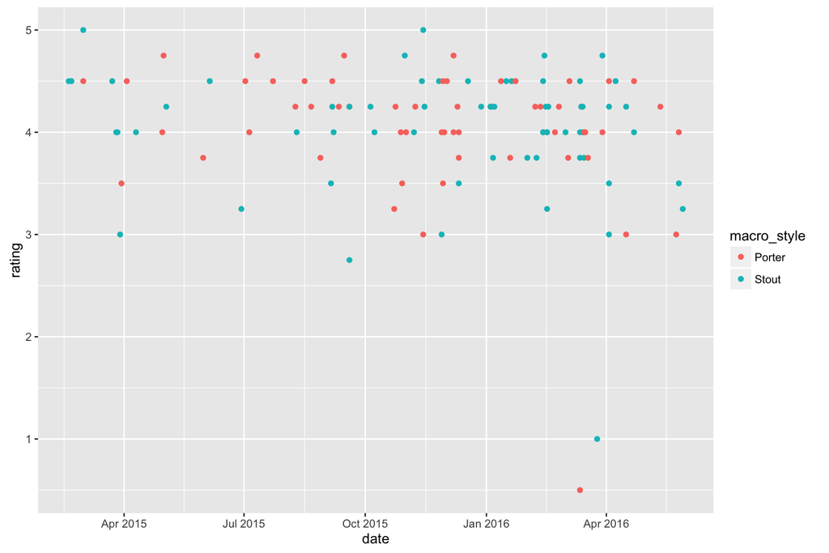

```r
ggplot(stouts_porters, aes(x = date, y = rating)) +
  geom_point(aes(color = macro_style))
```

This is still a little tricky to see. Let’s focus on the median rating for each day for both porters and stouts. First we need to compute the median ratings:

```r
sp_median <- stouts_porters %>% group_by(macro_style, date) %>%
  summarize(median_rating = median(rating))
```

Now we will create a line-graph over the time frame and color by `macro_style`:

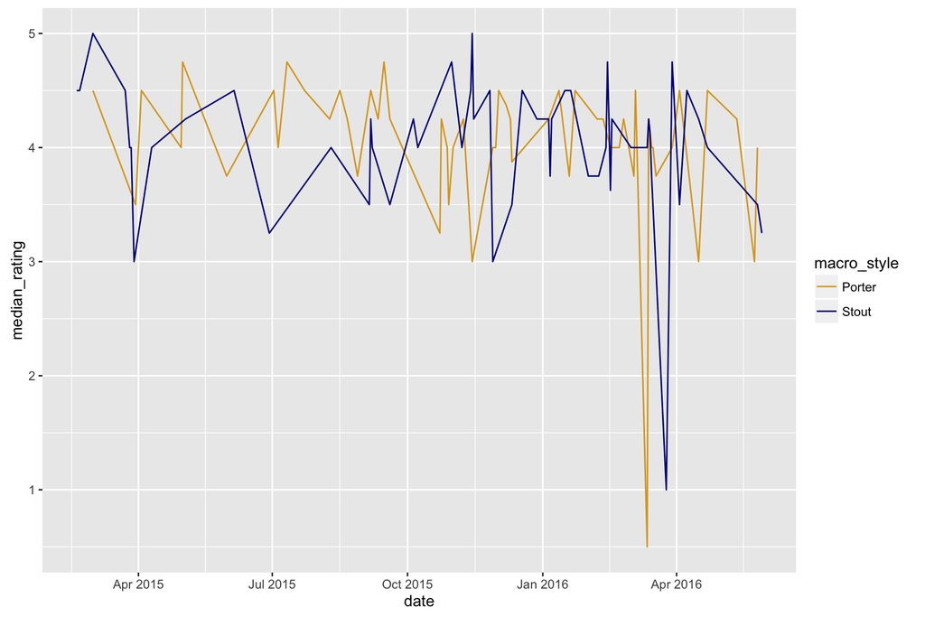

```r
ggplot(sp_median, aes(x = date, y = median_rating, color = macro_style)) +
    geom_line() +
  scale_color_manual(values = c("goldenrod", "darkblue"))
```

It does appear that I prefer porters to stouts in the summer months, stouts to porters in the fall, and it is anybody’s guess for the remainder of the year.

Play around with the data more to see which kinds of correlations and things stand out to you!